# LD loss simulations with meta analysis

Author

Gibran Hemani

Published

May 31, 2023

LD loss analysis asks

Simulations:

1. For a causal variant being discovered in European datasets, what are the possible top GWAS hits
2. What is the probability of each SNP being top hit in the region
3. What is the average expected LD between causal variant and European-discovered top hit in non-Europeans
4. What is the difference in allele frequencies between Eur and non-Eur for the Eur top hit

Analysis:

5. Are the known GWAS hits giving a different cross-population result from other LD/MAF matched SNPs
6. What is expected influence on MR
- Using European bgx against non-European bgy
- Using re-estimated bgx against bgy in non-Europeans
- Consider bias due to LD, weak instrument bias, power

Now allow the initial discovery GWAS to be a meta-analysis with EUR and AFR. Does it improve the LD loss in other populations?

```r
library(here)
renv::activate(here(".."))
library(dplyr)
library(ggplot2)
library(lmerTest)
library(lme4)
library(simulateGP)
```

```r
load(here("../output_set1/results2.rdata"))
# remove duplicate SNPs

res <- res[!duplicated(paste(res$snp, res$pop, res$pval, res$prop_afr)),]
res$rsidcode <- paste(res$snp, res$pval)
table(table(paste(res$snp, res$pval)))
```

```
   15
11815
```

```r
dim(res)
```

```
[1] 177225     11
```

LD loss

The sample size doesn’t have much impact on the decay of LD. But the discovery p-value has a big impact it seems - at least on an absolute scale

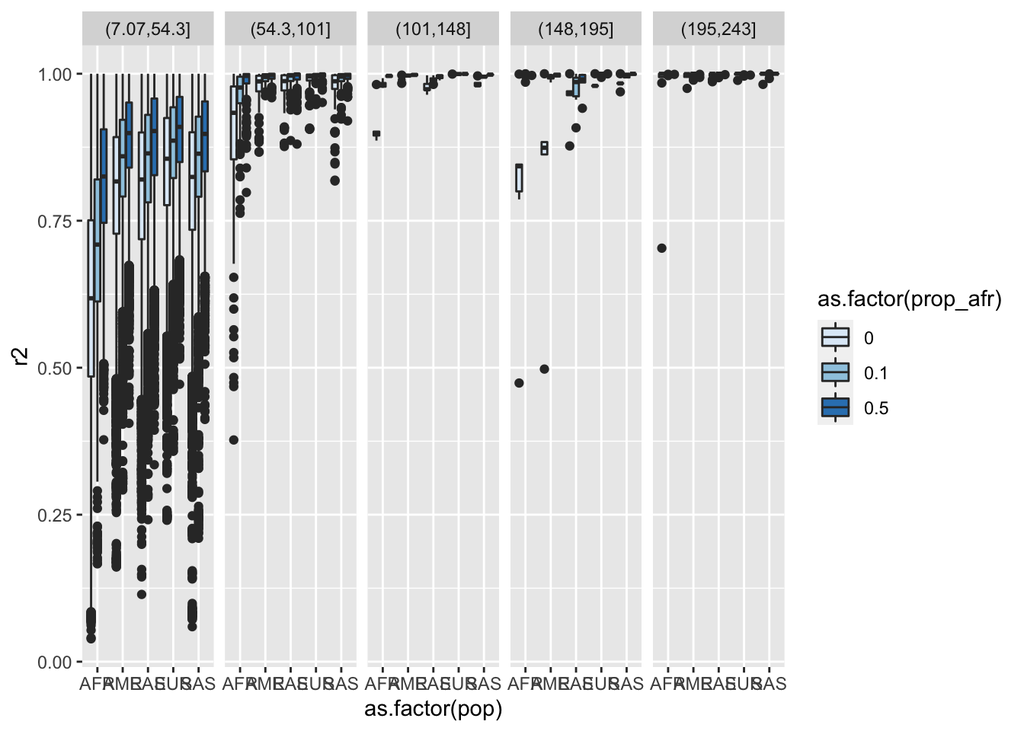

```r
res %>%
  mutate(pvalbin = cut(-log10(pval), 5)) %>%
  ggplot(., aes(y=r2, x=as.factor(pop))) +
  geom_boxplot(aes(fill=as.factor(prop_afr))) +
  facet_grid(. ~ pvalbin) +
  scale_fill_brewer(type="seq")
```

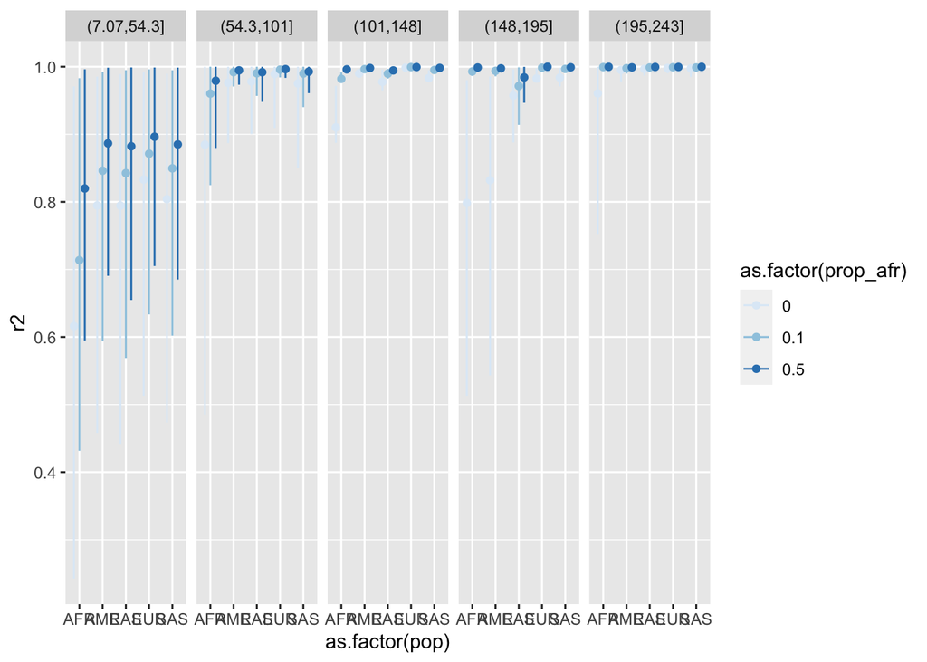

```r
ress <- res %>%
  ungroup() %>%
  mutate(pvalbin = cut(-log10(pval), 5)) %>%
  group_by(pop, prop_afr, pvalbin) %>%
  summarise(uci=quantile(r2, 0.975, na.rm=T), lci=quantile(r2, 0.025, na.rm=T), r2=mean(r2, na.rm=T))
ress %>%
  ggplot(., aes(y=r2, x=as.factor(pop))) +
  geom_point(aes(colour=as.factor(prop_afr)), position=position_dodge(width=0.7)) +
  geom_errorbar(aes(ymin=lci, ymax=uci, colour=as.factor(prop_afr)), position=position_dodge(width=0.7), width=0) +
  facet_grid(. ~ pvalbin) +
  scale_colour_brewer(type="seq")
```